# Risk Policy

Sarah Gaichas

2026-10-23

## 1 Introduction

The MAFMC Risk Policy was identified as a high priority decision for further indicator integration. The current [Risk Policy](https://www.federalregister.gov/documents/2020/12/15/2020-27562/fisheries-of-the-northeastern-united-states-omnibus-framework-adjustment-to-modify-the-mid-atlantic) uses one indicator, stock biomass status, to determine the Council’s risk policy with respect to probability of overfishing. Low stock status (B/Bmsy < 1) results in much more risk averse probability of overfishing and lower ABC relative to OFL, high stock status (>1.5 B/Bmsy) is as risk tolerant as allowed by law with ABC close to OFL.

The current Risk Policy was finalized by the Council in [December 2020](https://www.federalregister.gov/documents/2020/12/15/2020-27562/fisheries-of-the-northeastern-united-states-omnibus-framework-adjustment-to-modify-the-mid-atlantic). It is based on a [management strategy evaluation](https://static1.squarespace.com/static/511cdc7fe4b00307a2628ac6/t/5e56e0f286208b151ba4f55d/1582752007474/S1_Fine+tuning+the+ABC+control+rule+for+Mid-Atlantic+stocks_Wiedenmann.pdf) that compared performance of alternative policies across life history types represented by summer flounder, scup, and butterfish.

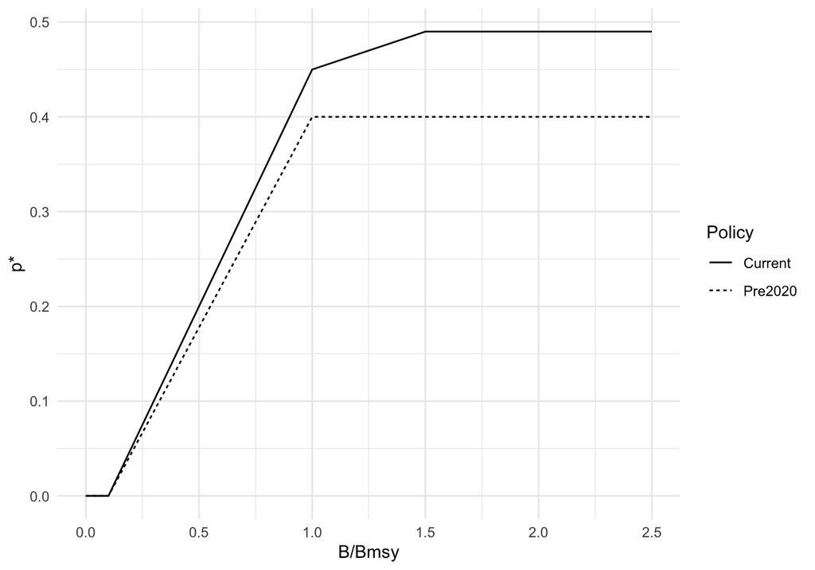

The [ABC control rule](http://www.mafmc.org/s/MAFMC-ABC-Control-Rule-White-Paper.pdf) includes an SSC decision on uncertainty in the assessment and converts the risk policy into an ABC given the stock status.

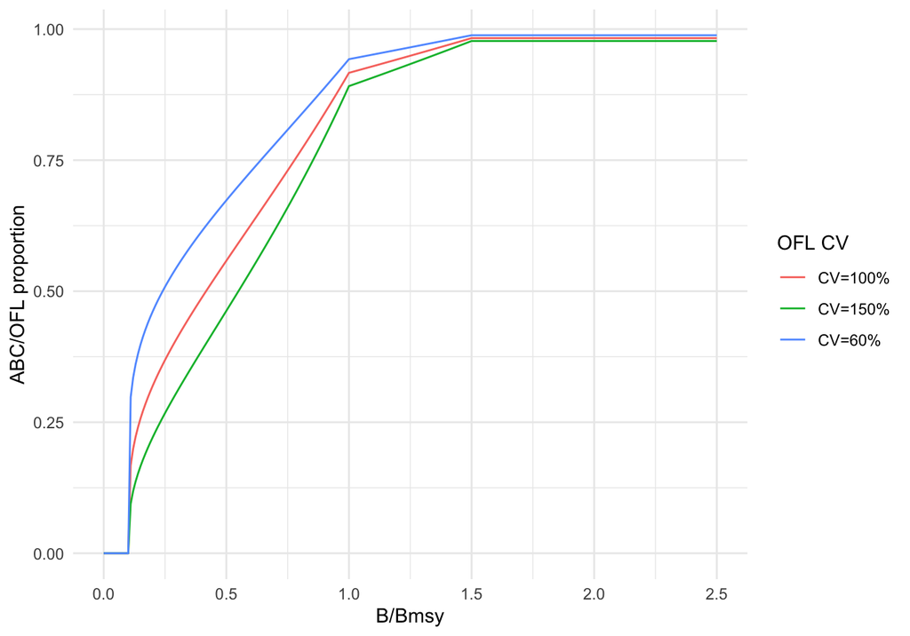

## 2 Direction from the Mini Workshop

Approach: adjustment to current processes with indicators, not invention of new processes. Maintain a general (rather than species tailored) approach for the risk policy, and maintain the current simplicity.

Socioeconomic indicators were identified as a promising area for development, particularly for risk policy, given that the current framework relies almost exclusively on biological indicators.

**Guiding question:** What is the range of acceptable tradeoffs between social/economic considerations and stock status at a given level of overfishing risk? Can the use of multiple indicators increase stability in advice?

**Initial needs**

- Documentation for each time Council has suspended the risk policy.

The Council suspended the risk policy for spiny dogfish in 2025, setting ABC=OFL (the maximum legal ABC) due to concerns related to MSA National Standard 8. From October 2024 Council Report: “industry provided input that the resulting lower quotas could collapse the spiny dogfish fishery by forcing the last processor out of business.” In 2025, the Council set spiny dogfish 2026-2027 ABC equal to 2025 ABC, slightly less than the projected OFL for those years.

- Request code from Weidenmann for 2019 risk policy MSE. (done)

**Focus on social and economic indicators**

- Integrate concerns that caused risk policy suspension.
- Review current SOE, Risk Assessment, SSB Performance.
- Draw dataset from Fishery Performance reports.

## 3 A potential indicator-based framework

### 3.1 Identify the decision

Risk policy: Council decides whether to apply the standard biology-based risk policy, or modify with social and economic factors? How much weight should social and economic factors get?

### 3.2 Identify key information

#### 3.2.1 Which are the most important two factors to consider for the decision? Combined socioeconomic and biological?

My reading of the Council action on spiny dogfish is that the goal is maintaining fishery viability, and the mechanism was preventing the loss of essential fishery infrastructure resulting from volumes to low for the single processor.

The fishery is reliant on a single processor and has no other options for landing dogfish catch.

#### 3.2.2 What indicators do we have for the factors?

For the dogfish case, specific indicators would be number of processors available for a particular species (1), and volume required for the processor to stay open (we don’t have that).

To generalize this, we suggest looking at existing regional socioeconomic indicators specifying the landings/revenue by species at each port to find the set of ports most reliant on the species in question. Or we could ask how many ports have more than X% of revenue from this species. Or what is the maximum proportion of revenue for this species in any port?

The new commercial fishing port activity indicator could be used–what proportion is this species of all activity at this port? Find the top X ports.

Then, for this subset of ports, evaluate the diversity of options for revenue–how many other species generate revenue in those ports? What other options are there for these ports to generate revenue?

### 3.3 Identify clear decision criteria

What threshold values move us between decisions?

Brainstorm: Some are identified above as Xs. The bottom line is don’t let the last processor go away but what is above that? We could use history (lowest revenue observed from the species in any port? quantiles of revenue?) and maybe the biodiversity lit has some ideas on minimum or optimal values of diversity?

### 3.4 Conceptual model for decisions

The “square” approach uses a pair of indicators and identifies how decisions change across their joint range. In one quadrant, the joint indicators have good status, in the opposite quadrant both have poor status. The other two quadrants have a mix of good and poor status across the indicators. Each quadrant leads to a different decision. The thresholds are then the values of each indicator dividing good from poor.

For risk policy, a square representing fishery viability could include one indicator for the reliance of the fishery on the species (represented as aggregated ports with high landings of the species), and the other could be the diversity of landings in the same ports, representing other economic options for dependent ports.

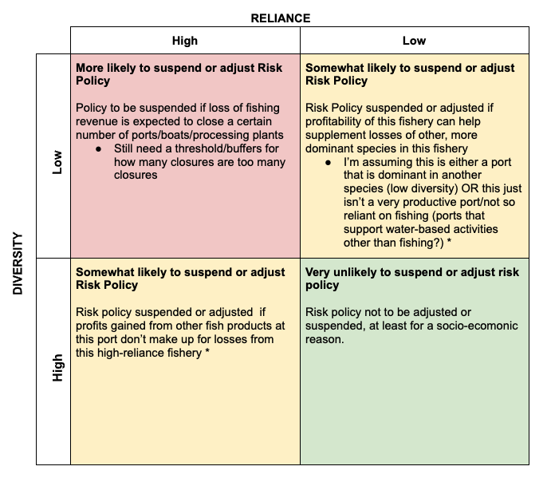

What we would test is how these different decisions based on indicators might tradeoff with stock status in the case of the risk policy, since these decisions have the potential to override the standard risk policy.

What does it mean to “suspend” the risk policy? Essentially it means allowing the maximum risk tolerance regardless of stock status; setting ABC = OFL. This is what has happened for spiny dogfish for the 2025 specifications. However, the current spiny dogfish specifications have ABC slightly less than the projected OFL to temper the risk of overfishing while maintaining enough catch to retain regional processing capacity.

With the use of indicators of fishery viability, the risk policy could instead be adjusted to increase risk tolerance at lower stock status than currently prescribed to balance socioeconomic objectives with stock status objectives.

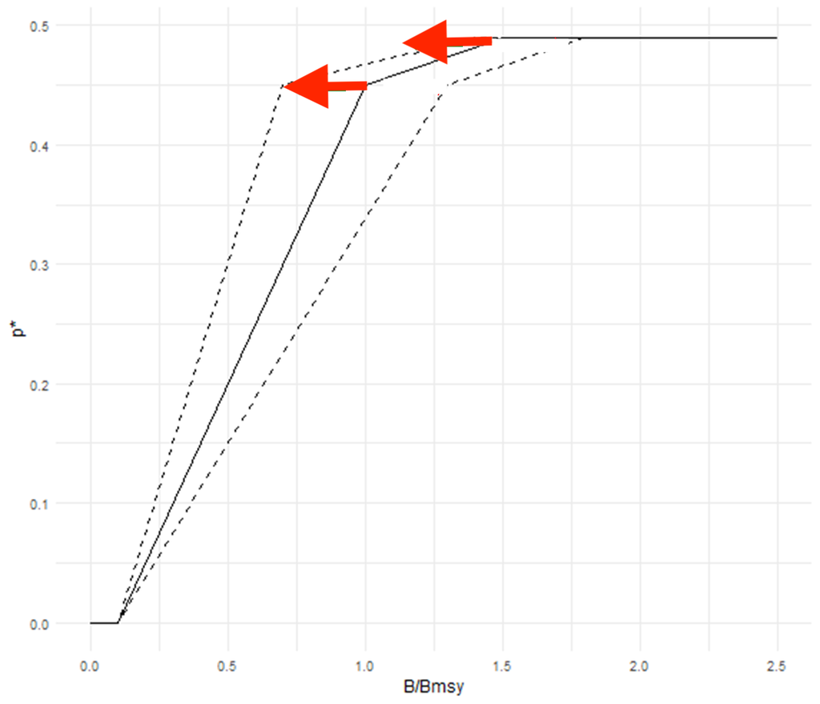

In particular, the time dimension will be important. Suspending the risk policy for a single year may not have a big impact on stock status but over multiple years it could, compromising the Council’s future options if the stock status reaches the overfished threshold and a rebuilding plan is required. Low stock status has further implications for the social and economic outcomes measured by the indicators.

What level of catch is required to meet the social and economic objectives? If it is above the legal limit (can’t exceed OFL) then what?

## 4 Simulation ideas

We have a [food web](https://sgaichas.github.io/MAB-Rpath/MAB_MSE_test.html) and a [single species simulation framework](https://sgaichas.github.io/spasam-mse-test/ButterfishTest_MAFMC_HCR.html) with the MAFMC risk policy implemented.

A simple test in the absence of indicators would be to test various levels of risk policy suspension with various durations to see whether and when stock status drops to levels requiring rebuilding. This could identify the safe space for making policy calls to prioritize socioeconomic objectives in the short term. Once a stock is at the level requiring rebuilding there are fewer management options combined with fishery restrictions counterproductive to socioeconomic objectives. So low stock status still needs to be avoided.

The [commercial performance measures](https://apps-nefsc.fisheries.noaa.gov/pm/index.php) give economic performance indicators at the FMP and prices at the species level over time so we could bracket revenues for a given amount of catch. In the food web model we could do this for all species so we could know what proportion of total revenue each species has and also get an overall revenue diversity metric. This could be done by fleet.

In the single species model we would need to have scenarios of high and low reliance and other options for fleets just built in.

## 5 Approach

The first step informs thresholds for decision making, when to depart from standard risk policy based on socioeconomic factors. The second informs how much to depart from the risk policy and for how long before stock status is compromised, removing flexibility. When do we depart from standard risk policy and what is the safe operating space?

### 5.1 Develop indicators based on data for use in the square:

- Ask Tarsila for data underlying the current [Community Risk Indicators](https://noaa-edab.github.io/catalog/community_risks.html)
  - Need port (community?) specific landings and revenue by species: use this data to get indicators for how important a species is to the top ports (reliance) and what other options they have (diversity), see if there are natural breakpoints for thresholds by species
  - Secondary [social vulnerability](https://noaa-edab.github.io/catalog/engagement.html) indicators for use in the yellow squares to decide whether to alter risk policy or keep standard from Bobby: high gentrification risk could imply loss of coastal infrastructure that exacerbates socioeconomic risk and may lead to higher risk tolerance
  - Is there any state level recreational landings by species or something that would give us a rec equivalent? POT would like to see this tried, there are port specific recreational “engagement” and “reliance” indicators but I suspect they do not have species level information. So can we combine those with rec landings by state to get some idea of where the top communities might be for each species?

**Specific data request:**

Ideally we would have the time series of actual landings and revenue values by port for each species. I’m going to send in an NDA form to GARFO to see if we can just get permission to use this data. Then we can recombine however we need.

If that is not approved:

- The time series of species level proportion of commercial landings and proportion of commercial revenue by port (or whatever community identifier is least aggregated)
- A few ranks reflecting long term importance and recent importance
  - For each MAFMC species, rank order of ports from highest to lowest long term (entire time series) average landings
  - For each MAFMC species, rank order of ports from highest to lowest long term (entire time series) average revenue
  - For each MAFMC species, rank order of ports from highest to lowest recent 3 year average landings
  - For each MAFMC species, rank order of ports from highest to lowest recent 3 year average revenue
- MAFMC species list:

mafmc <- c(“Atlantic Mackerel”, “Black Sea Bass”, “Bluefish”, “Blueline Tilefish”, “Butterfish”, “Chub mackerel”, “Golden Tilefish”, “Northern Shortfin Squid”, “Longfin Inshore Squid”, “Scup”, “Spiny Dogfish”, “Summer Flounder”, “Surf Clam”, “Ocean Quahog”)

### 5.2 Use MAB Rpath to test departures from standard risk policy

Use MAB Rpath to test consequences of different levels and durations of departures from standard risk policy for target species and other managed species and fleets:

(Initial work to ensure fleets are scaled properly for MAFMC species and have discards for dogfish)

MSE with ecosense, following the test example [here](https://sgaichas.github.io/MAB-Rpath/MAB_MSE_test.html)

- Generate an ensemble of feasible MAB Rpath parameterizations; in each:
  - Simulate a strong fishing signal (none, heavy, recovery) and collect biomass and catch “data” for MAFMC species
  - Fit each MAFMC species to a production model (Gavin to supply code)
  - Production model parameters –> single species reference points for use in the MAFMC risk policy
  - Base simulation is 20 years under standard risk policy *but test different ways to allocate effort to achieve TAC*
  - Alternative simulations lower the B/Bmsy ratio where max p* is applied by species individually. Our series of p* = 0.49 could be at 10% intervals around Bmsy, but that is a lot of runs. If we do this for 20 years we can find the number of years applied before the stock crashed? Ideally would want to see if the stock can recover from risk policy suspension. So maybe apply relaxed risk policy for 3 years then revert, 5 years then revert, 10 years then revert in the full 20 year projection

Now each sense run has a base simulation and many alternatives for relative comparisons